# Airline Route Profitability

2026-04-19

# Introduction

Airlines operate in one of the most cost-intensive industries in the world, so understanding what makes a flight profitable is important for route planning, fleet management, and revenue strategy. This project analyzes a simulated one-year dataset of flight-level financial data for a major Middle Eastern airline operating from Dubai (DXB). Because Dubai is a global hub connecting regional, medium-distance, and intercontinental destinations, it is a strong setting for studying how different route types influence profitability.

The goal of this analysis is to answer a business question: **What factors are most strongly associated with airline profitability?** In particular, this report investigates whether profitability is more strongly affected by route category, season, demand level, or load factor.

To answer this question, the report uses data cleaning, grouped summaries, tables, and visualizations. The analysis focuses on key variables such as **Profit**, **Profit_Margin**, **Load_Factor**, **Season**, **Demand_Level**, and **Route_Category**. The final goal is not only to identify which flights make more money, but also to understand which flights are more efficient and why.

# Packages Required

```r
# tidyverse: data import, wrangling, and plotting
library(tidyverse)

# tidyr: reshaping data into tidy format
library(tidyr)

# lubridate: converting and working with dates
library(lubridate)

# knitr: making clean summary tables
library(knitr)

# scales: formatting labels as dollars and percentages
library(scales)
```

# Data Preparation

## Data Source

The dataset used in this project is the **Airline Route Profitability Dataset** from Kaggle by **Muhammad Waleed**:

[Airline Route Profitability Dataset](https://www.kaggle.com/datasets/waleedfaheem/airline-route-profitability-and-cost-analysis?resource=download)

This dataset simulates a full year of flight-level financial data for a major Middle Eastern carrier based in Dubai (DXB). Each row represents a single flight, and the data includes route category, season, demand, aircraft type, passenger load, revenue, costs, and profit.

The airline operates across three route categories:

- **Short-Haul (1 to 3.5 hours):** DOH, MCT, KWI, BAH, RUH, JED, CAI, AMM
- **Medium-Haul (2.5 to 7 hours):** BOM, DEL, IST, LHR, BLR, HYD, MAA, KHI, LHE, CMB
- **Long-Haul (6.5 to 16.5 hours):** JFK, SYD, MEL, SIN, HKG, BKK, KUL, CDG, FRA, LAX, SFO, ORD

## Load and Clean the Data

```r
airline_data <- read_csv("airline_route_profitability.csv")
```

```r
# Replace missing numeric values with the median
airline_clean <- airline_data %>%
  mutate(across(where(is.numeric),
                ~ ifelse(is.na(.), median(., na.rm = TRUE), .)))

# Replace missing text values with "Unknown"
airline_clean <- airline_clean %>%
  mutate(across(where(is.character),
                ~ ifelse(is.na(.), "Unknown", .))) %>%
  mutate(Flight_Date = ymd(Flight_Date))
```

## Check Missing Values After Cleaning

```r
missing_after <- airline_clean %>%
  summarize(across(everything(), ~ sum(is.na(.)))) %>%
  pivot_longer(cols = everything(),
               names_to = "Variable",
               values_to = "Missing_After") %>%
  filter(Missing_After > 0)

kable(missing_after, caption = "Remaining Missing Values After Cleaning")
```

Remaining Missing Values After Cleaning

| Variable | Missing_After |
| --- | --- |

## Final Dataset Size

```r
dataset_shape <- tibble(
  Rows = nrow(airline_clean),
  Columns = ncol(airline_clean)
)

kable(dataset_shape, caption = "Final Dataset Size")
```

Final Dataset Size

| Rows | Columns |
| --- | --- |
| 7974 | 33 |

## Summary of Key Variables

```r
key_variables <- tibble(
  Variable = c("Profit", "Profit_Margin", "Load_Factor", "Route_Category", "Season", "Demand_Level"),
  Description = c(
    "Net earnings per flight after total costs",
    "Profit as a percentage of total revenue",
    "Proportion of seats filled on a flight",
    "Short-, medium-, or long-haul route grouping",
    "Season category assigned in the dataset",
    "Demand intensity assigned to each flight"
  ),
  Why_Important = c(
    "Main outcome variable",
    "Measures efficiency instead of just scale",
    "Measures how full the aircraft was",
    "Represents route scale and operating pattern",
    "Captures seasonal demand timing",
    "Captures customer demand pressure"
  )
)

kable(key_variables, caption = "Key Variables Used in the Analysis")
```

Key Variables Used in the Analysis

| Variable | Description | Why_Important |
| --- | --- | --- |
| Profit | Net earnings per flight after total costs | Main outcome variable |
| Profit_Margin | Profit as a percentage of total revenue | Measures efficiency instead of just scale |
| Load_Factor | Proportion of seats filled on a flight | Measures how full the aircraft was |
| Route_Category | Short-, medium-, or long-haul route grouping | Represents route scale and operating pattern |
| Season | Season category assigned in the dataset | Captures seasonal demand timing |
| Demand_Level | Demand intensity assigned to each flight | Captures customer demand pressure |

# Correct Season Definitions from the Actual Dataset

After checking the actual CSV, the season labels in the dataset correspond to the following month groupings:

- **Peak:** January to February and December
- **Shoulder:** March to April and October to November
- **Normal:** May and September
- **Low:** June to August

This correction is important because it changes the interpretation of the seasonal and monthly profit results.

# Exploratory Data Analysis

## Profit Summary by Season

```r
profit_by_season <- airline_clean %>%
  group_by(Season) %>%
  summarize(
    Avg_Profit = mean(Profit, na.rm = TRUE),
    Avg_Profit_Margin = mean(Profit_Margin, na.rm = TRUE),
    Flight_Count = n(),
    .groups = "drop"
  ) %>%
  arrange(desc(Avg_Profit))

kable(profit_by_season, digits = 2, caption = "Average Profit and Margin by Season")
```

Average Profit and Margin by Season

| Season | Avg_Profit | Avg_Profit_Margin | Flight_Count |
| --- | --- | --- | --- |
| Peak | 110278.75 | 17.55 | 2002 |
| Shoulder | 82675.09 | 10.14 | 2646 |
| Normal | 63480.49 | 3.33 | 1325 |
| Low | 25903.39 | -8.50 | 2001 |

With the corrected season definitions, the pattern is clear and internally consistent: **Peak** performs best, followed by **Shoulder**, then **Normal**, while **Low** performs worst.

## Profit Summary by Route Category

```r
profit_by_route <- airline_clean %>%
  group_by(Route_Category) %>%
  summarize(
    Avg_Profit = mean(Profit, na.rm = TRUE),
    Avg_Profit_Margin = mean(Profit_Margin, na.rm = TRUE),
    Flight_Count = n(),
    .groups = "drop"
  ) %>%
  arrange(desc(Avg_Profit))

kable(profit_by_route, digits = 2, caption = "Average Profit and Margin by Route Category")
```

Average Profit and Margin by Route Category

| Route_Category | Avg_Profit | Avg_Profit_Margin | Flight_Count |
| --- | --- | --- | --- |
| Long Haul | 160410.04 | 22.71 | 3225 |
| Medium Haul | 30232.15 | 12.96 | 2563 |
| Short Haul | -8841.14 | -26.12 | 2186 |

## Profit Summary by Demand Level

```r
profit_by_demand <- airline_clean %>%
  group_by(Demand_Level) %>%
  summarize(
    Avg_Profit = mean(Profit, na.rm = TRUE),
    Avg_Profit_Margin = mean(Profit_Margin, na.rm = TRUE),
    Flight_Count = n(),
    .groups = "drop"
  ) %>%
  arrange(desc(Avg_Profit))

kable(profit_by_demand, digits = 2, caption = "Average Profit and Margin by Demand Level")
```

Average Profit and Margin by Demand Level

| Demand_Level | Avg_Profit | Avg_Profit_Margin | Flight_Count |
| --- | --- | --- | --- |
| High | 107463.74 | 17.69 | 4630 |
| Medium | 23302.49 | -9.73 | 3344 |

Demand level shows one of the strongest patterns in the dataset. High-demand flights consistently outperform medium-demand flights in both total profit and profit margin.

# Research Questions

## 1. How does profit spread across all flights?

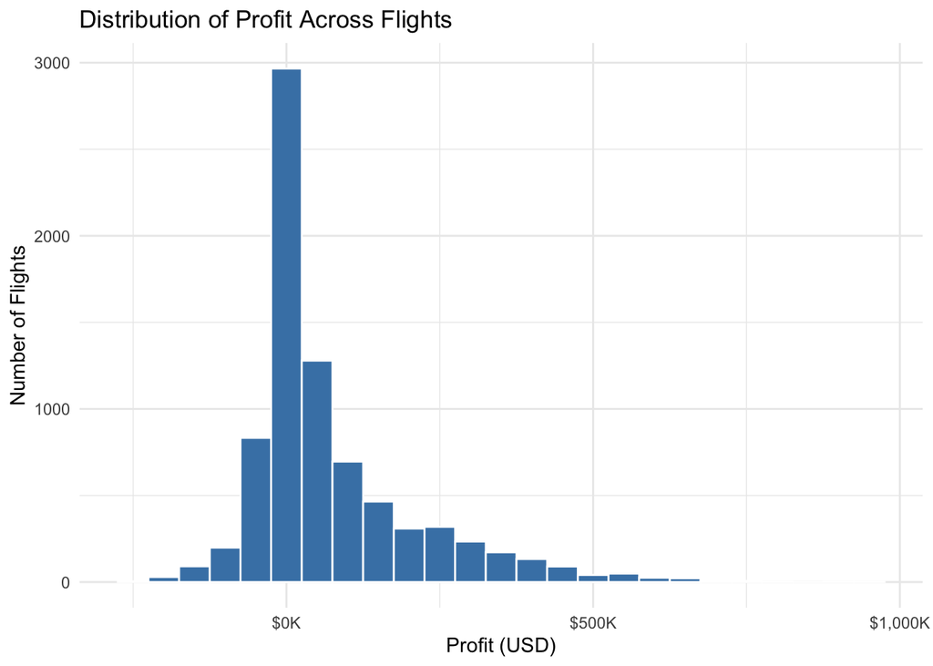

```r
ggplot(airline_clean, aes(x = Profit)) +
  geom_histogram(binwidth = 50000, fill = "steelblue", color = "white") +
  scale_x_continuous(labels = dollar_format(scale = 1e-3, suffix = "K")) +
  labs(
    title = "Distribution of Profit Across Flights",
    x = "Profit (USD)",
    y = "Number of Flights"
  ) +
  theme_minimal()
```

## 2. Are long-haul routes more profitable than short-haul routes?

```r
route_summary <- airline_clean %>%
  group_by(Route_Category) %>%
  summarize(
    Flight_Count = n(),
    Avg_Profit = mean(Profit, na.rm = TRUE),
    Median_Profit = median(Profit, na.rm = TRUE),
    Avg_Profit_Margin = mean(Profit_Margin, na.rm = TRUE),
    .groups = "drop"
  )

kable(route_summary, digits = 2, caption = "Profit Summary by Route Category")
```

Profit Summary by Route Category

| Route_Category | Flight_Count | Avg_Profit | Median_Profit | Avg_Profit_Margin |
| --- | --- | --- | --- | --- |
| Long Haul | 3225 | 160410.04 | 145271.11 | 22.71 |
| Medium Haul | 2563 | 30232.15 | 28196.63 | 12.96 |
| Short Haul | 2186 | -8841.14 | -5710.52 | -26.12 |

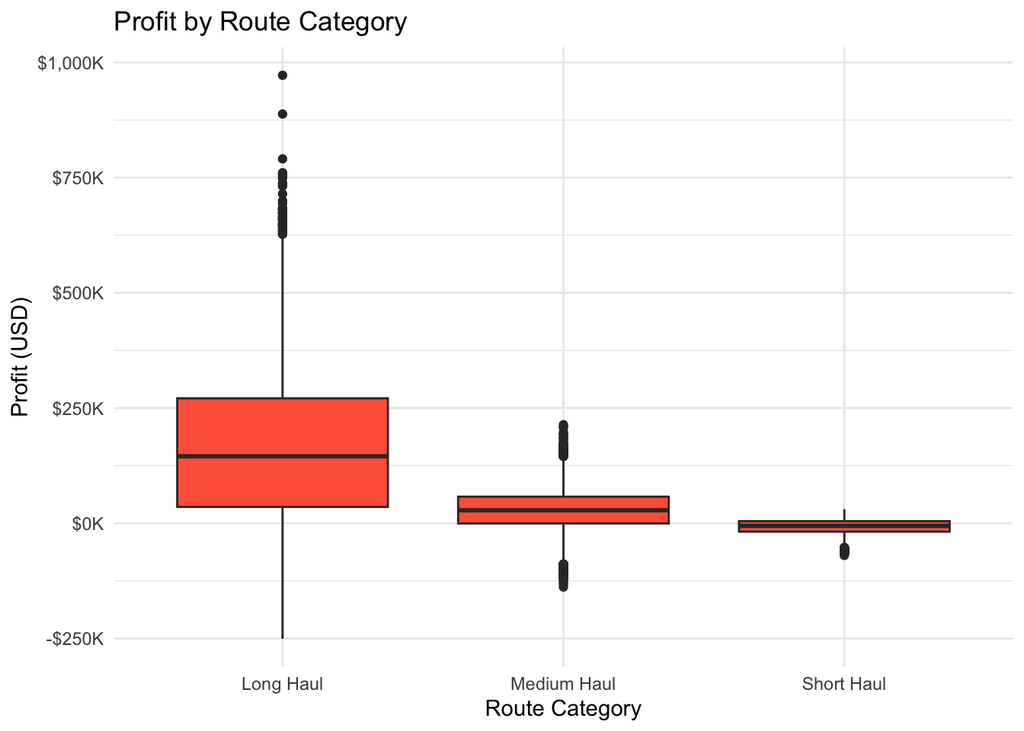

```r
ggplot(airline_clean, aes(x = Route_Category, y = Profit)) +
  geom_boxplot(fill = "tomato") +
  scale_y_continuous(labels = dollar_format(scale = 1e-3, suffix = "K")) +
  labs(
    title = "Profit by Route Category",
    x = "Route Category",
    y = "Profit (USD)"
  ) +
  theme_minimal()
```

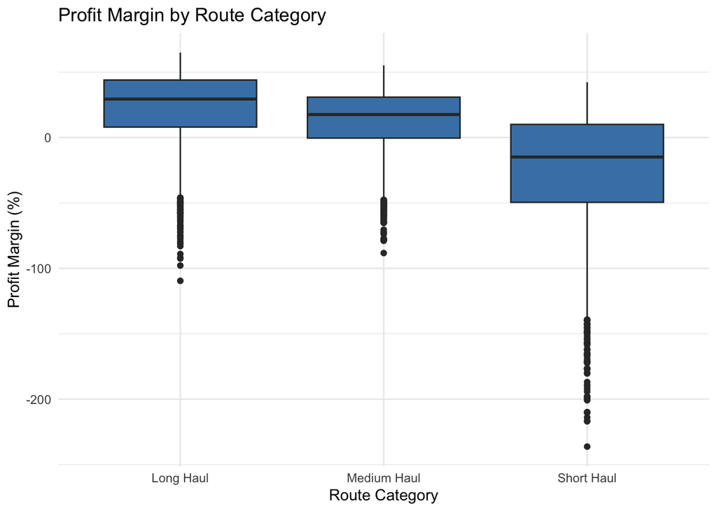

```r
ggplot(airline_clean, aes(x = Route_Category, y = Profit_Margin)) +
  geom_boxplot(fill = "steelblue") +
  labs(
    title = "Profit Margin by Route Category",
    x = "Route Category",
    y = "Profit Margin (%)"
  ) +
  theme_minimal()
```

## 3. Does season affect profitability?

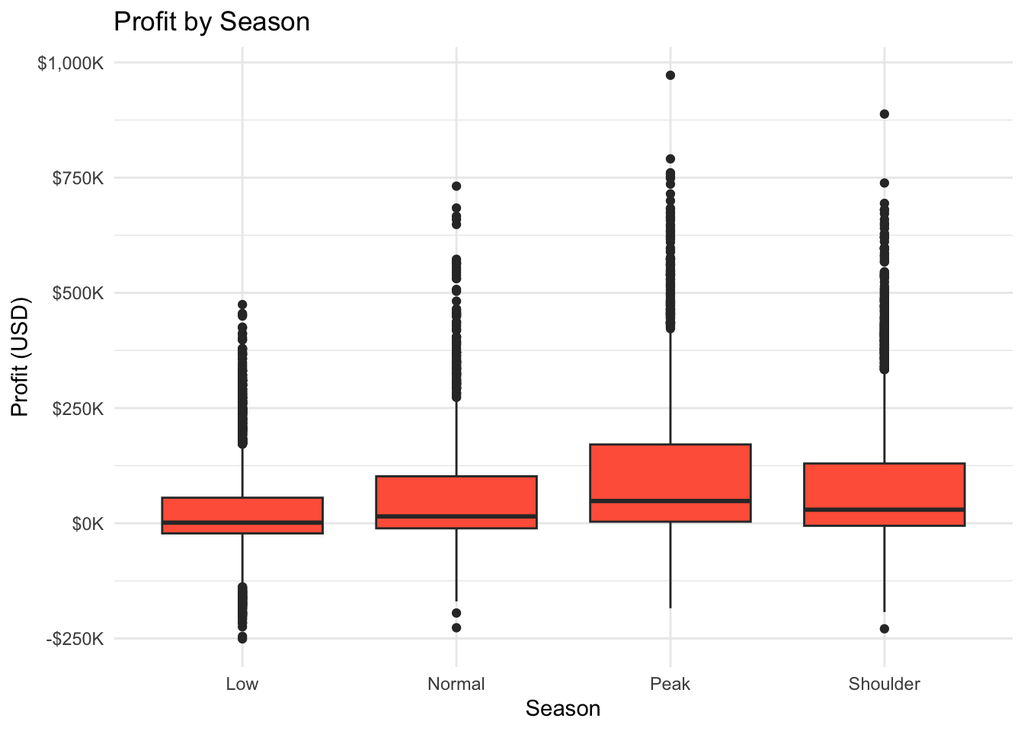

```r
ggplot(airline_clean, aes(x = Season, y = Profit)) +
  geom_boxplot(fill = "tomato") +
  scale_y_continuous(labels = dollar_format(scale = 1e-3, suffix = "K")) +
  labs(
    title = "Profit by Season",
    x = "Season",
    y = "Profit (USD)"
  ) +
  theme_minimal()
```

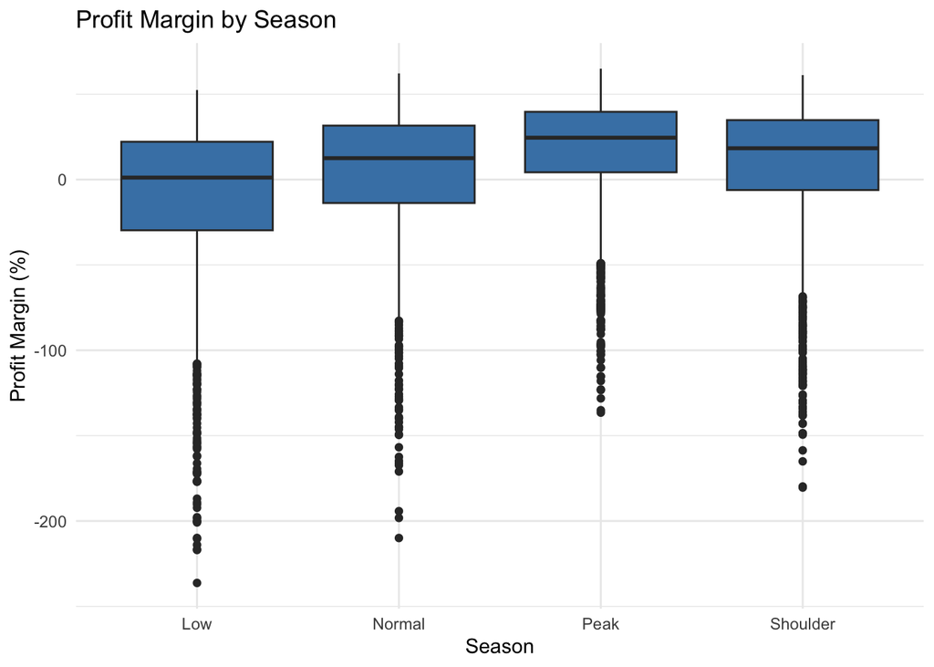

```r
ggplot(airline_clean, aes(x = Season, y = Profit_Margin)) +
  geom_boxplot(fill = "steelblue") +
  labs(
    title = "Profit Margin by Season",
    x = "Season",
    y = "Profit Margin (%)"
  ) +
  theme_minimal()
```

With the corrected definitions, season clearly affects profitability. Peak season has the strongest performance, while Low season has the weakest.

## 4. How does demand level influence profitability?

```r
demand_summary <- airline_clean %>%
  group_by(Demand_Level) %>%
  summarize(
    Flight_Count = n(),
    Avg_Profit = mean(Profit, na.rm = TRUE),
    Median_Profit = median(Profit, na.rm = TRUE),
    Avg_Profit_Margin = mean(Profit_Margin, na.rm = TRUE),
    Median_Profit_Margin = median(Profit_Margin, na.rm = TRUE),
    .groups = "drop"
  )

kable(demand_summary, digits = 2, caption = "Profit Summary by Demand Level")
```

Profit Summary by Demand Level

| Demand_Level | Flight_Count | Avg_Profit | Median_Profit | Avg_Profit_Margin | Median_Profit_Margin |
| --- | --- | --- | --- | --- | --- |
| High | 4630 | 107463.74 | 43018.31 | 17.69 | 21.91 |
| Medium | 3344 | 23302.49 | 2530.11 | -9.73 | 1.67 |

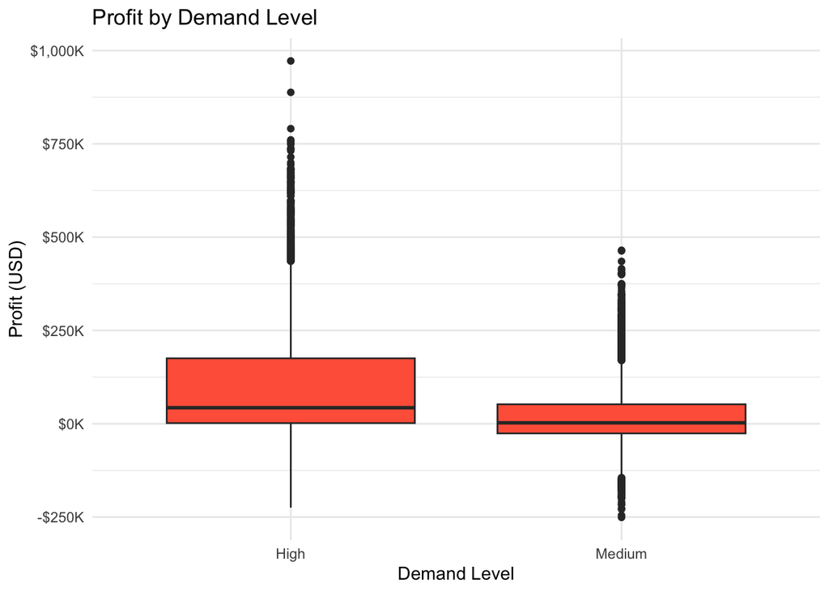

```r
ggplot(airline_clean, aes(x = Demand_Level, y = Profit)) +
  geom_boxplot(fill = "tomato") +
  scale_y_continuous(labels = dollar_format(scale = 1e-3, suffix = "K")) +
  labs(
    title = "Profit by Demand Level",
    x = "Demand Level",
    y = "Profit (USD)"
  ) +
  theme_minimal()
```

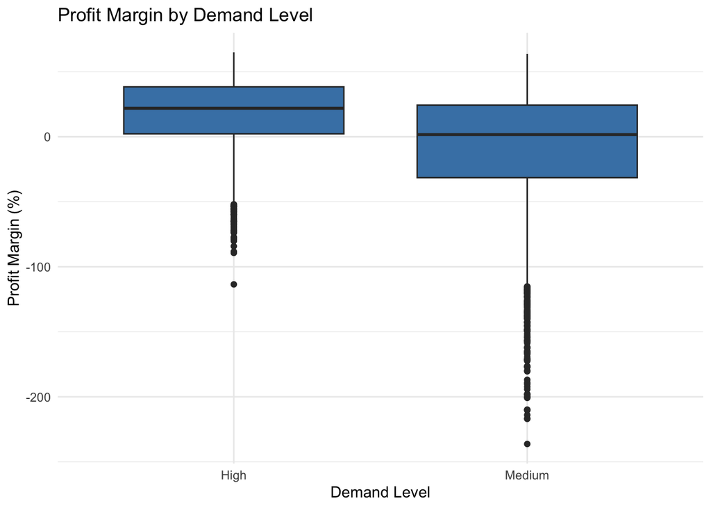

```r
ggplot(airline_clean, aes(x = Demand_Level, y = Profit_Margin)) +
  geom_boxplot(fill = "steelblue") +
  labs(
    title = "Profit Margin by Demand Level",
    x = "Demand Level",
    y = "Profit Margin (%)"
  ) +
  theme_minimal()
```

## 5. Do fuller flights lead to higher profit?

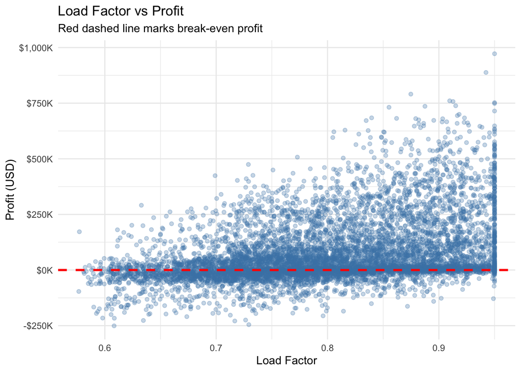

```r
ggplot(airline_clean, aes(x = Load_Factor, y = Profit)) +
  geom_point(alpha = 0.3, color = "steelblue") +
  geom_hline(yintercept = 0, color = "red", linetype = "dashed", linewidth = 1) +
  scale_y_continuous(labels = dollar_format(scale = 1e-3, suffix = "K")) +
  labs(
    title = "Load Factor vs Profit",
    subtitle = "Red dashed line marks break-even profit",
    x = "Load Factor",
    y = "Profit (USD)"
  ) +
  theme_minimal()
```

All flights in this dataset already have a high load factor, so the data looks compact and clustered. Even then, a lot of flights still fall below the break-even line. This tells us that load factor alone does not guarantee profitability. Other fixed costs like fuel, crew salaries, and airport fees also play a significant role.

## 6. Is profit more influenced by season or by demand level?

```r
season_compare <- airline_clean %>%
  group_by(Season) %>%
  summarize(
    Avg_Profit = mean(Profit, na.rm = TRUE),
    Avg_Profit_Margin = mean(Profit_Margin, na.rm = TRUE),
    .groups = "drop"
  ) %>%
  mutate(Group_Type = "Season",
         Group = Season) %>%
  select(Group_Type, Group, Avg_Profit, Avg_Profit_Margin)

demand_compare <- airline_clean %>%
  group_by(Demand_Level) %>%
  summarize(
    Avg_Profit = mean(Profit, na.rm = TRUE),
    Avg_Profit_Margin = mean(Profit_Margin, na.rm = TRUE),
    .groups = "drop"
  ) %>%
  mutate(Group_Type = "Demand Level",
         Group = Demand_Level) %>%
  select(Group_Type, Group, Avg_Profit, Avg_Profit_Margin)

comparison_table <- bind_rows(season_compare, demand_compare)

kable(comparison_table, digits = 2, caption = "Comparing Season and Demand Level Effects")
```

Comparing Season and Demand Level Effects

| Group_Type | Group | Avg_Profit | Avg_Profit_Margin |
| --- | --- | --- | --- |
| Season | Low | 25903.39 | -8.50 |
| Season | Normal | 63480.49 | 3.33 |
| Season | Peak | 110278.75 | 17.55 |
| Season | Shoulder | 82675.09 | 10.14 |
| Demand Level | High | 107463.74 | 17.69 |
| Demand Level | Medium | 23302.49 | -9.73 |

Season matters much more than it seemed before the correction, but demand level still shows the cleanest overall profitability split.

## 7. Which season and route combinations are most profitable?

```r
combo_summary <- airline_clean %>%
  group_by(Season, Route_Category) %>%
  summarize(
    Flight_Count = n(),
    Avg_Profit = mean(Profit, na.rm = TRUE),
    Avg_Profit_Margin = mean(Profit_Margin, na.rm = TRUE),
    .groups = "drop"
  ) %>%
  arrange(desc(Avg_Profit))

kable(combo_summary, digits = 2, caption = "Profitability by Season and Route Category")
```

Profitability by Season and Route Category

| Season | Route_Category | Flight_Count | Avg_Profit | Avg_Profit_Margin |
| --- | --- | --- | --- | --- |
| Peak | Long Haul | 812 | 230395.04 | 31.54 |
| Shoulder | Long Haul | 1068 | 181075.91 | 26.02 |
| Normal | Long Haul | 533 | 149345.35 | 22.06 |
| Low | Long Haul | 812 | 70506.73 | 9.95 |
| Peak | Medium Haul | 643 | 55383.42 | 23.74 |
| Shoulder | Medium Haul | 849 | 36260.97 | 16.67 |
| Normal | Medium Haul | 424 | 20026.77 | 9.44 |
| Low | Medium Haul | 647 | 4013.20 | -0.32 |
| Peak | Short Haul | 547 | -3499.55 | -10.51 |
| Shoulder | Short Haul | 729 | -7429.86 | -20.74 |
| Normal | Short Haul | 368 | -10817.31 | -30.84 |
| Low | Short Haul | 542 | -14788.44 | -45.90 |

The strongest combination is **Peak + Long Haul**, while **Low + Short Haul** is the weakest.

## 8. How does profit change month by month?

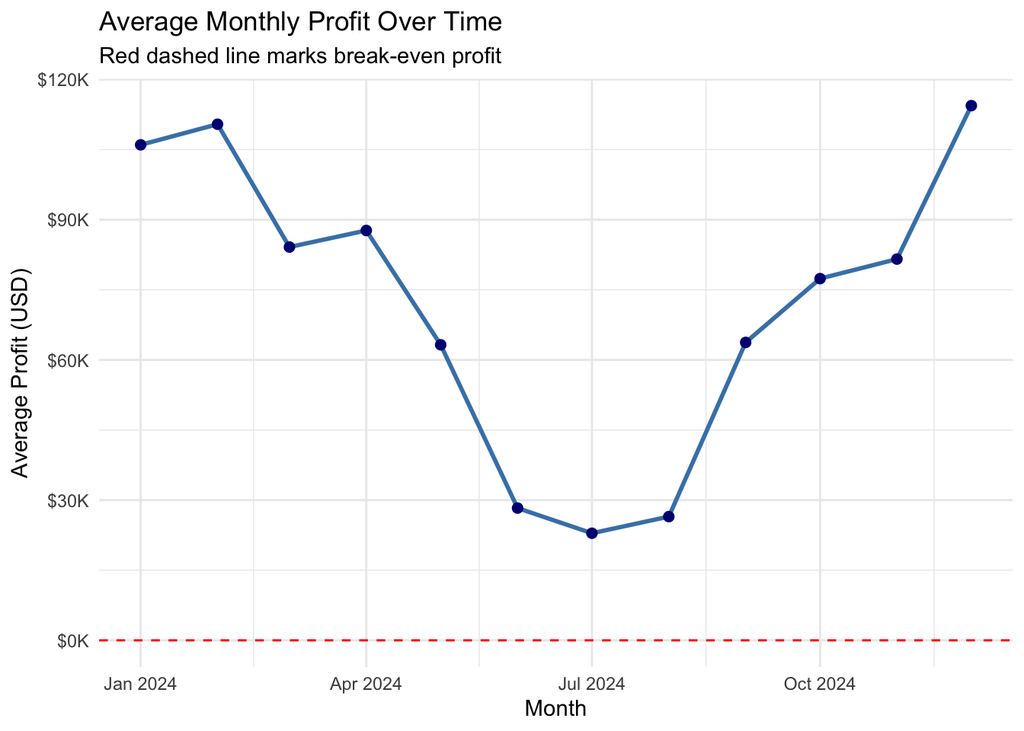

```r
monthly_profit <- airline_clean %>%
  mutate(Month = floor_date(Flight_Date, unit = "month")) %>%
  group_by(Month) %>%
  summarize(
    Avg_Profit = mean(Profit, na.rm = TRUE),
    .groups = "drop"
  )

ggplot(monthly_profit, aes(x = Month, y = Avg_Profit)) +
  geom_line(color = "steelblue", linewidth = 1) +
  geom_point(color = "navy", size = 2) +
  geom_hline(yintercept = 0, color = "red", linetype = "dashed") +
  scale_y_continuous(labels = dollar_format(scale = 1e-3, suffix = "K")) +
  labs(
    title = "Average Monthly Profit Over Time",
    subtitle = "Red dashed line marks break-even profit",
    x = "Month",
    y = "Average Profit (USD)"
  ) +
  theme_minimal()
```

The monthly trend is consistent with the dataset’s season definitions. Winter months perform best because they fall into Peak season, while summer months perform worst because they fall into Low season.

# Conclusion

This report studied the profitability of airline routes for a simulated Dubai-based airline using a full year of flight-level financial data. The goal was to identify whether route category, season, demand level, or load factor had the strongest relationship with profit.

## Limitations

This dataset is simulated rather than taken directly from a real airline, so the findings should be interpreted as realistic modeled patterns rather than exact operational truth. In addition, the data reflects one Dubai-based airline setting, so the results may not apply equally to every airline business model.

## Future Improvements

Future work could explore profitability by aircraft type, by specific destination, or through predictive modeling using demand, season, route category, and load factor.